# My First R Markdown Document

N.Paterno

Before starting any lab, be sure to change the author and date in the yaml header to be your name and today’s date. Note that the further along we get in the semester, the less explanatory information will be written out in labs. For example, the reminder to change the author and date will not be in every lab but you’re still expected to do so.

The goal of this lab is to compile your first R Markdown document and get a sneak peak of what we’ll be doing in lab the next two weeks.

## Summmary Statistics

We are going to use the gpa_study_hours data set from the openintro package. Before we view the dataset lets open the help file in the Directory pane. Click the ‘Help’ tab and search for ‘gpa_study_hours’. Let’s view the dataset. You can choose to either run the code chunk below or type the command into your Console.

```r
View(gpa_study_hours)
```

Below is a code and output for the calculating the average gpa.

```r
mean(gpa_study_hours$gpa)
```

```
## [1] 3.586166
```

mean() is a function in R that will calculate the average of a numeric variable. The syntax for the argument outside of a pipe (explained below) is dataset$variable. Inside of a pipe only the variable is needed.

The pipe-operator, %>% , is a key part of Tidyverse syntax. It tells us to take whatever is on the left side of the argument “and then” perform the next line of code. To calculate the average gpa using the pipe-operator:

```r
gpa_study_hours %>%
  summarize(mean(gpa))
```

```
## # A tibble: 1 x 1
##   `mean(gpa)`
##         <dbl>
## 1        3.59
```

This above chunk of code tells us to take the gpa_study_hours data set “and then” summarize the data by calculating the mean of the gpa variable.

The two methods we just used - without and with the pipe-operator - are considered Base R and Tidyverse syntax, respectively. Both methods are equally valid. For the remainder of our labs we will primarily use Tidyverse syntax as it is a bit more fluid.

## Histograms

Here we will sketch a histogram of the gpa of these students.

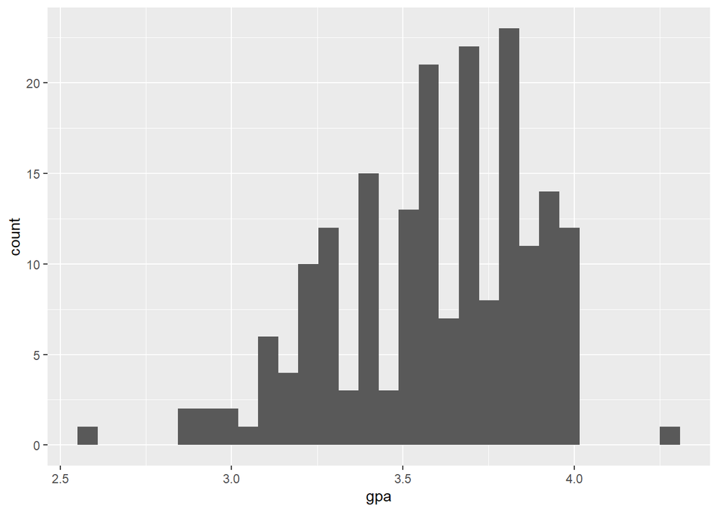

```r
ggplot(data = gpa_study_hours,
       aes(x = gpa))+
  geom_histogram()
```

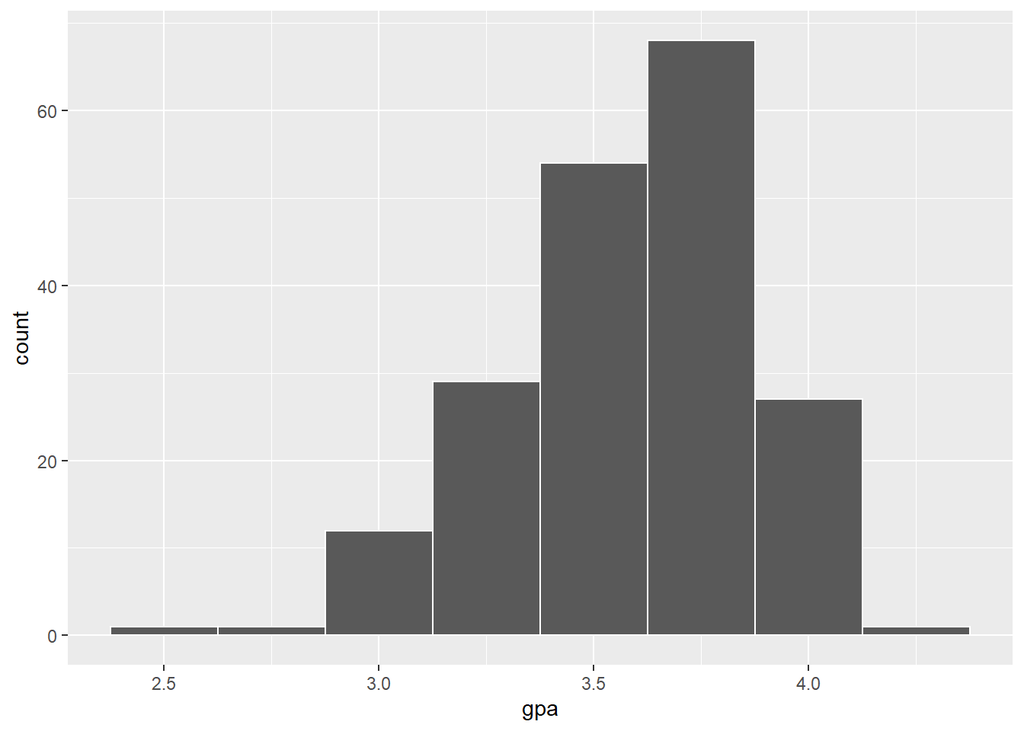

```r
ggplot(data = gpa_study_hours,
       aes(x = gpa))+
  geom_histogram(color = "White", binwidth = 0.25)
```